# DINEMITES Tutorial

William Nickols

willnickols@g.harvard.edu

## Introduction

**DINEMITES** (**Di**stinguishing **Ne**w **M**alaria **I**nfections in **T**im**e** **S**eries) is a comprehensive R package for distinguishing new from persistent infections in longitudinal sequencing data. It is intended for use with longitudinal malaria studies, but it can be applied to any longitudinal data in which people can acquire a disease with multiple variants multiple times.

If you use the DINEMITES software, please cite our work:

> William A. Nickols, Philipp Schwalb, Daniel Neafsey. In progress: Statistical models distinguish new malaria infections in time series sequencing data.

### Support

For issues, bugs, or questions, please open an issue at https://github.com/WillNickols/dinemites/issues.

## Contents

- 1. Installing R
- 2. Installing DINEMITES
- 3. Distinguishing new infections
  - 3.1 DINEMITES input
  - 3.2 Imputing qPCR only time points
  - 3.3 Setting up covariates
  - 3.4 Running models
- 4. Analyzing results
  - 4.1 Merging probabilities
  - 4.2 New complexity of infection
  - 4.3 New infections
  - 4.4 Data visualization

## 1. Installing R

[R](https://www.r-project.org/) is a programming language specializing in statistical computing and graphics. You can use R just the same as any other programming languages, but it is most useful for statistical analyses, with well-established packages for common tasks such as [linear modeling](https://cran.r-project.org/web/packages/lme4/index.html), [’omic data analysis](https://bioconductor.org/), [machine learning](http://topepo.github.io/caret/index.html), and [visualization](https://ggplot2.tidyverse.org/).

#### Installing R for the first time

You can download and install the free R software environment [here](https://cloud.r-project.org/). Note that you should download the latest release - this will ensure the R version you have is compatible with MaAsLin 3.

#### The RStudio IDE

[RStudio](https://rstudio.com/products/rstudio/) is a freely available IDE (integrated development environment) for R. It is a “wrapper” around R with some additional functionalities that make programming in R a bit easier. Feel free to download RStudio and explore its interface - but it is not required for this tutorial.

#### Important: the correct R version

If you already have R installed, then it is possible that the R version you have does not support DINEMITES The easiest way to check this is to launch R/RStudio, and in the console (“Console” pane in RStudio), type in the following command (without the `>` symbol):

[session information not shown]

The first line of output message should indicate your current R version. For example:

```
> sessionInfo()
R version 4.4.1 (2024-06-14)
```

For DINEMITES to install, you will need R >= 3.4. If your version is older than that, please refer to section Installing R for the first time to download the latest R. Note that RStudio users will need to have RStudio “switch” to this later version once it is installed. This should happen automatically for Windows and Mac OS users when you relaunch RStudio. For Linux users you might need to bind the correct R executable. Either way, once you have the correct version installed, launch the software and use `sessionInfo()` to make sure that you indeed have R >= 3.4.

## 2. Installing DINEMITES

**Before installing DINEMITES**, `cmdstanr` must be installed. To do so, run the following commands:

```r
install.packages("cmdstanr",
                 repos = c('https://stan-dev.r-universe.dev',
                           getOption("repos")))
cmdstanr::install_cmdstan()
```

Then, the latest version of DINEMITES can be installed from GitHub.

```r
if (!require("devtools", quietly = TRUE))
    install.packages("devtools")

devtools::install_github("WillNickols/dinemites")
```

## 3. Distinguishing new infections

### 3.1 DINEMITES input

#### Sequencing input

At a minimum, DINEMITES requires a data frame of sequenced infections with the columns `allele`, `time`, and `subject`. The `allele` column should have the name of the genetic variant sequenced in the sample (e.g., `A206G`, `pfama1.21`, `11`). The `time` column should be a numeric value denoting when the sample was collected (typically the number of days since the start of the study). The `subject` column should be a subject identifier for the person who contributed the sample. If multiple variants are detected at the same time point for the same person, there should be multiple rows with the same `subject` and `time` but different values in `allele`. If some samples do not have any sequenced variants (i.e., no infection), rows should be included with the corresponding `time` and `subject` but `NA` in the `allele` column. **If samples without infections are not included, the downstream results could be very biased.** If multiple loci are sequenced, the locus name of the allele should be included in the `locus` column. Allele names should still be unique even across loci. In this data frame, other sample-specific information can be included including covariates that affect the rate at which a person becomes infected (`season`, LLIN usage, etc.).

Here, we’ll use a synthetic dataset of 5 subjects sequenced at 2 loci created to compactly illustrate the features of DINEMITES.

```r
suppressPackageStartupMessages(library(dinemites))
suppressPackageStartupMessages(library(dplyr))
dataset <- read.csv(system.file(package="dinemites","extdata","dataset.tsv"),
                    header = TRUE, sep="\t")
```

| allele | time | subject | season | locus |
| --- | --- | --- | --- | --- |
| 11 | 14 | 2 | 0 | 2 |
| 1 | 14 | 4 | 0 | 1 |
| 8 | 14 | 4 | 0 | 1 |
| 10 | 14 | 4 | 0 | 1 |
| 11 | 14 | 4 | 0 | 2 |
| 18 | 14 | 4 | 0 | 2 |

|  | allele | time | subject | season | locus |
| --- | --- | --- | --- | --- | --- |
| 98 | NA | 122 | 5 | 1 | NA |
| 99 | NA | 126 | 1 | 1 | NA |
| 100 | NA | 126 | 2 | 1 | NA |
| 101 | NA | 126 | 4 | 1 | NA |
| 102 | NA | 140 | 2 | 1 | NA |
| 103 | NA | 140 | 4 | 1 | NA |

The function `fill_in_dataset` then takes the dataset and turns it into its complete format by creating a row for each allele for each subject and time and adding a `present` column that is 0 or 1 depending on whether the allele was absent or present:

```r
dataset <- fill_in_dataset(dataset)
```

| allele | time | subject | season | locus | present |
| --- | --- | --- | --- | --- | --- |
| 1 | 1 | 1 | 0 | 1 | 0 |
| 4 | 1 | 1 | 0 | 1 | 0 |
| 5 | 1 | 1 | 0 | 1 | 0 |
| 7 | 1 | 1 | 0 | 1 | 0 |
| 8 | 1 | 1 | 0 | 1 | 0 |
| 9 | 1 | 1 | 0 | 1 | 0 |
| 10 | 1 | 1 | 0 | 1 | 0 |
| 11 | 1 | 1 | 0 | 2 | 0 |
| 13 | 1 | 1 | 0 | 2 | 0 |
| 14 | 1 | 1 | 0 | 2 | 0 |
| 16 | 1 | 1 | 0 | 2 | 0 |
| 17 | 1 | 1 | 0 | 2 | 0 |
| 18 | 1 | 1 | 0 | 2 | 0 |
| 19 | 1 | 1 | 0 | 2 | 0 |
| 20 | 1 | 1 | 0 | 2 | 0 |
| 1 | 1 | 2 | 0 | 1 | 0 |
| 4 | 1 | 2 | 0 | 1 | 0 |
| 5 | 1 | 2 | 0 | 1 | 0 |
| 7 | 1 | 2 | 0 | 1 | 0 |
| 8 | 1 | 2 | 0 | 1 | 0 |
| 9 | 1 | 2 | 0 | 1 | 0 |
| 10 | 1 | 2 | 0 | 1 | 0 |
| 11 | 1 | 2 | 0 | 2 | 0 |
| 13 | 1 | 2 | 0 | 2 | 0 |
| 14 | 1 | 2 | 0 | 2 | 0 |
| 16 | 1 | 2 | 0 | 2 | 0 |
| 17 | 1 | 2 | 0 | 2 | 0 |
| 18 | 1 | 2 | 0 | 2 | 0 |
| 19 | 1 | 2 | 0 | 2 | 0 |
| 20 | 1 | 2 | 0 | 2 | 0 |

[output cut: 70 more lines]

#### qPCR only input

If some time points are known to have infections but don’t have sequencing information (e.g., because ultrasensitive qPCR was used before sequencing), these points can be included as a data frame with columns `subject` and `time`. These points should also be included in the original data frame with `allele` set to `NA`.

```r
qPCR_only <- read.csv(system.file(package="dinemites","extdata","qPCR_only.tsv"),
                      header = TRUE, sep="\t")
```

| subject | time |
| --- | --- |
| 4 | 1 |
| 5 | 87 |
| 3 | 109 |
| 2 | 126 |

These qPCR-only time points are then added to the dataset, where they replace the `present` values for all alleles at the corresponding subject time with the value `2`.

```r
dataset <- add_qpcr_times(dataset, qpcr_times = qPCR_only)
```

| allele | time | subject | season | locus | present |
| --- | --- | --- | --- | --- | --- |
| 1 | 1 | 4 | 0 | 1 | 2 |
| 4 | 1 | 4 | 0 | 1 | 2 |
| 5 | 1 | 4 | 0 | 1 | 2 |
| 7 | 1 | 4 | 0 | 1 | 2 |
| 8 | 1 | 4 | 0 | 1 | 2 |
| 9 | 1 | 4 | 0 | 1 | 2 |

#### Treatments

Additionally, a data frame of treatments can be provided with a `subject` and `time` column indicating when individuals were treated for infections. The treatments included in this data frame should only be those expected to clear malaria infections (not simply treating fever etc.).

```r
treatments <- read.csv(system.file(package="dinemites","extdata","treatments.tsv"),
                       header = TRUE, sep="\t")
```

| subject | time |
| --- | --- |
| 3 | 140 |
| 5 | 140 |

#### Data visualization

We can visualize the infection time series for one of the subjects using the `plot_single_subject` function. In the plot below, each X indicates the presence of a sequenced parasite allele, and they are connected by colored lines if the same allele is observed multiple times. The red line indicates that a qPCR-only infection occurred on day 109, and the blue line indicates that the person received treatment on day 140.

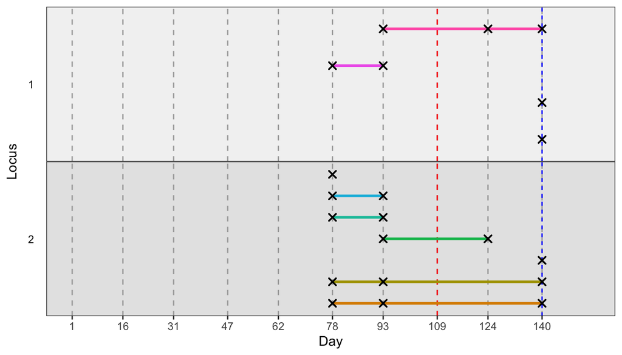

```r
plot_single_subject(3, dataset, treatments)
```

### 3.2 Imputing qPCR only time points

When some time points are only known to be qPCR positive, multiple imputation is used to create multiple datasets with the qPCR positive time points replaced probabilistically by specific alleles. Multiple imputation is a widely used statistical technique to handle missing data by generating multiple copies of the dataset with the missing values replaced by values imputed from the rest of the data. In this multiple imputation, alleles are inferred based on which alleles were present at the other, sequenced time points for the subject, using patterns learned from parts of the dataset with complete sequencing data.

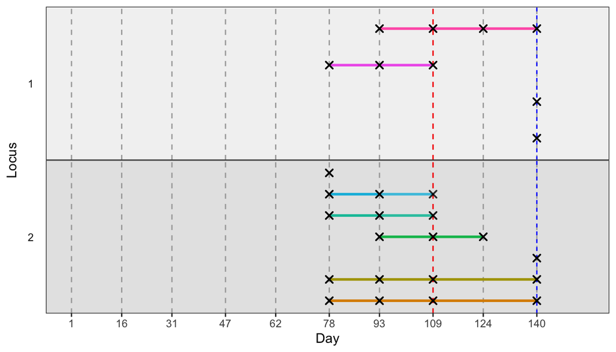

```r
set.seed(1)
n_imputations <- 10
imputed_datasets <- impute_dataset(dataset,
                                   n_imputations = n_imputations,
                                   verbose = FALSE)
dataset$probability_present <- rowMeans(imputed_datasets)
plot_single_subject(3, dataset, treatments)
```

In the plot, we see that the ambiguous infection on day 109 has been imputed to consist of specific alleles (the opacity `alpha` is equal to the proportion of times the allele is imputed to be present). The alleles that occur both before and after day 109 are imputed to be present most confidently while those not seen after day 93 are less confidently imputed.

### 3.3 Setting up covariates

DINEMITES includes three models for distinguishing old from persistent infections: a Bayesian model, a clustering model, and a simple model. The simple model and clustering model do not use information beyond allele presence and absence patterns, but the Bayesian model relies on modeling the rate at which infections occur newly and after previous infections. To this end, a variety of covariates can be included that affect the probability an infection will be observed at a given time for a given subject. The following code adds columns, for each imputed dataset:

1. `add_present_infection`: Adds an indicator of whether there is an infection from any allele.
2. `add_persistent_column`: Adds an indicator of whether there has been an infection with each row’s allele before that time. This corresponds to the intuition that the probability of observing an allele at any point in the future might be higher than at baseline because the parasite might still be present, even if not typically detectable.
3. `add_persistent_infection`: Adds an indicator of whether there has been an infection from any allele before that row’s time.
4. `add_lag_column`: Adds an indicator of whether there has been an infection with each row’s allele in the last `30` (default) days. This corresponds to the intuition that the probability of observing an allele again shortly after observing the allele is higher than at baseline because the parasite is likely still present.
5. `add_lag_infection`: Adds an indicator of whether there has been an infection with any row’s allele in the last `30` (default) days.
6. `add_treatment_column`: Adds indicators of whether there was treatment for the row’s allele between 1 and 10 days ago (default) for the `treatment_acute` column and 10 or more days ago (default) for the `treatment_longitudinal` column. This also sets the `persistent` and `lag_30` columns generated in (2) and (4) to 0 after treatment. This corresponds to the intuition that being treated should clear out parasites and therefore return the person to having no infections. However, the new columns allow the Bayesian model to account for incomplete clearance either shortly after or substantially after treatment.
7. `add_treatment_infection`: Adds indicators of whether there was treatment for any allele between 1 and 10 days ago (default) for the `treatment_acute_infection` column and 10 or more days ago (default) for the `treatment_longitudinal_infection` column. This also sets the `persistent_infection` and `lag_infection_30` columns generated in (2) and (4) to 0 after treatment.

For each of these functions, the `column` version is specific to the allele (i.e., was this allele observed recently?) while the `infection` version applies to an infection by any allele (i.e., was any infection observed recently?). The functions `add_persistent_[column/infection]` should only be called once, but `add_lag_[column/infection]` can be called multiple times with different `lag_time` parameters to specify different time intervals over which there might be different probabilities of observing a persistent allele (e.g., 30, 60, and 90 days).

```r
library(doParallel)
library(foreach)
library(doRNG)
# Can replace with more cores if available
n_cores <- ifelse(detectCores() > 1, 2, 1)
cl <- makeCluster(n_cores)
registerDoParallel(cl)

# Store imputed datasets with resulting covariates as a list
datasets <- foreach(i = 1:n_imputations,
                    .packages = c('dinemites', 'dplyr')) %dopar% {
    # Copy original dataset and use the ith imputed vaules
    dataset_tmp <- dataset
    dataset_tmp$present <- imputed_datasets[,i]

    # Add all covariates for that imputed dataset
    dataset_tmp <- dataset_tmp %>%
        add_present_infection() %>%
        add_persistent_column() %>%
        add_persistent_infection() %>%
        add_lag_column() %>%
        add_lag_infection() %>%
        add_treatment_column(treatments = treatments, verbose = F) %>%
        add_treatment_infection(treatments = treatments, verbose = F)

    dataset_tmp
}

stopCluster(cl)
```

### 3.4 Running models

New infections can be identified with three models that assign a probability (including 0 or 1) to each observed allele of being from a new infection. Except for the Bayesian model in the non-default drop-out mode (more later), these are probabilities the observed allele is from a new infection relative to its last observation (if any). That is, if a single infection spans two visits and an allele is only picked up on the second visit, this is classified as new rather than persistent (though alleles that were sequenced on both days would likely be classified as persistent).

#### Simple model

```r
n_cores <- ifelse(detectCores() > 1, 2, 1)
cl <- makeCluster(n_cores)
registerDoParallel(cl)

# Run the simple model for each dataset and store the probabilities
# in a matrix, one column for each imputation
probabilities_simple_mat <-
    foreach(i = 1:n_imputations,
            .combine = cbind,
            .packages = c('dinemites', 'dplyr')) %dopar% {
    probabilities_simple <- determine_probabilities_simple(datasets[[i]])
    probabilities_simple$probability_new
}

stopCluster(cl)
```

#### Bayesian model

The second model for distinguishing new from persistent infections is a Bayesian model that models the rate at which new infections are acquired and the rate at which any infections (both new and persistent) and uses laws of conditional probability to find the probability an allele is new. The model is parameterized with general covariates that affect the rate at which new infections are acquired (the season, LLIN usage, etc.) and persistence covariates that affect how likely a persistent infection is to be observed again (whether the allele has ever been observed, has been observed in the last 30 days, etc.). A model is fit in Stan, and the posterior coefficient draws are used to estimate the probability each allele is new. The model will run with covariates taking on any values, but the model fits much faster when the covariates take only one of a few values (e.g., 0/1 indicators) by collapsing redundant observations in the likelihood function.

This model uses the covariates created in section 3.3 and should take a few minutes to run. The fit probabilities can also be read in from `system.file(package = "dinemites", "extdata", "probabilities_bayesian_mat.tsv")`.

Note: The Bayesian model can be run with `drop_out = TRUE` to allow alleles to be classified as persistent even if they have never been observed before due to sequencing drop-out. This is primarily intended for cases in which the estimated sequencing drop-out is above 50%, which can be estimated with `estimate_drop_out`.

```r
estimate_drop_out(dataset)
```

```
##         Drop out rate        Evaluated gaps Number present in gap
##                     0                     4                     4
```

```r
if (instantiate::stan_cmdstan_exists()) {
    n_cores <- ifelse(detectCores() > 1, 2, 1)
    cl <- makeCluster(n_cores)
    registerDoParallel(cl)

    probabilities_bayesian_mat <-
        foreach(i = 1:n_imputations,
                .combine = cbind,
                .packages = c('dinemites', 'dplyr')) %dorng% {
        probabilities_bayesian <- determine_probabilities_bayesian(
            dataset = datasets[[i]],
            infection_persistence_covariates =
                c("persistent_infection",
                  "lag_infection_30",
                  "treatment_acute_infection",
                  "treatment_longitudinal_infection"),
            infection_general_covariates =
                c("season"),
            alleles_persistence_covariates =
                c("persistent",
                  "lag_30",
                  "treatment_acute",
                  "treatment_longitudinal"))

        probabilities_bayesian$probability_new
        }

    stopCluster(cl)
} else {
    probabilities_bayesian_mat <- read.csv(system.file(package = "dinemites",
            "extdata",
            "probabilities_bayesian_mat.tsv"),
        header = FALSE,
        sep="\t")
}
```

#### Clustering model

The third model for distinguishing new from persistent infections is a clustering model that, for each subject, clusters alleles according to co-occurrence, finds optimal probabilities each allele is present in each cluster and each cluster is present at each time point, uses these to calculate the probability an allele is new.

```r
if (instantiate::stan_cmdstan_exists()) {
    n_cores <- ifelse(detectCores() > 1, 2, 1)
    cl <- makeCluster(n_cores)
    registerDoParallel(cl)

    probabilities_clustering_mat <-
        foreach(i = 1:n_imputations,
                .combine = cbind,
                .packages = c('dinemites', 'dplyr')) %dorng% {
            probabilities_clustering <-
                determine_probabilities_clustering(dataset = datasets[[i]])
            probabilities_clustering$probability_new
    }

    stopCluster(cl)
} else {
    probabilities_clustering_mat <- read.csv(system.file(package = "dinemites",
            "extdata",
            "probabilities_clustering_mat.tsv"),
        header = FALSE,
        sep="\t")
}
```

## 4. Analyzing results

### 4.1 Merging probabilities

First, we will add the probabilities to the dataset:

```r
dataset <- dataset %>%
    dplyr::mutate(probability_clustering =
                      rowMeans(probabilities_clustering_mat, na.rm = T),
                  probability_bayesian =
                      rowMeans(probabilities_bayesian_mat, na.rm = T))
```

We want one consensus probability rather than two columns of probabilities, so we will use the `merge_probability_columns` to combine the results from the Bayesian model and the clustering model. This function takes the average of the probabilities within the threshold (`0.3` by default) and allows us to select probabilities manually if they are sufficiently discordant. To ensure this file knits, we will just set `probability_new` to the Bayesian probabilities, but when run in an interactive session (e.g., Rstudio), running `merge_probability_columns` will display each discordant row and a plot highlighting the discordant value and ask the user to choose a probability. To try this, copy the chunk with `merge_probability_columns` into the console and run it.

```r
dataset <- dataset %>% dplyr::mutate(probability_new = probability_bayesian)
```

```r
dataset <- merge_probability_columns(dataset,
    c('probability_clustering', 'probability_bayesian'),
    threshold = 0.3)
```